# Speech Input Stats

### 5.4.3 Repeated measures ANOVA on transformed data

```r
anova = ezANOVA(datatr, dv=.(meanCorrTime), wid=.(participantNo), within=.(inputType,taskType), detailed=TRUE)
# kable(anova$`Mauchly's Test for Sphericity`)
# kable(anova$`Sphericity Corrections`)
# kable(anova$ANOVA)
anova_apa = anova_apa(anova, sph_corr ="gg", es = "ges", print=FALSE)
input = anova_apa$text[2]
task = anova_apa$text[3]
kable(anova_apa)
```

| effect | text |
| --- | --- |
| (Intercept) | F(1, 27) = 12234.69, p < .001, getasq > .99 |
| inputType | F(1, 27) = 25.74, p < .001, getasq = .18 |
| taskType | F(1, 27) = 24.86, p < .001, getasq = .14 |
| inputType:taskType | F(1, 27) = 5.63, p = .025, getasq = .03 |

# 6 Words per Minute

## 6.1 Chart

```r
kable(dplyr::select(data.stats, inputType, taskType, mWpm, sdWpm))
```

| inputType | taskType | mWpm | sdWpm |
| --- | --- | --- | --- |
| Keyboard | Composition | 35.12853 | 13.16359 |
| Keyboard | Transcription | 48.01401 | 14.95651 |
| Speech | Composition | 116.84166 | 63.67879 |
| Speech | Transcription | 156.99807 | 72.17769 |

## 6.2 Bar Graph

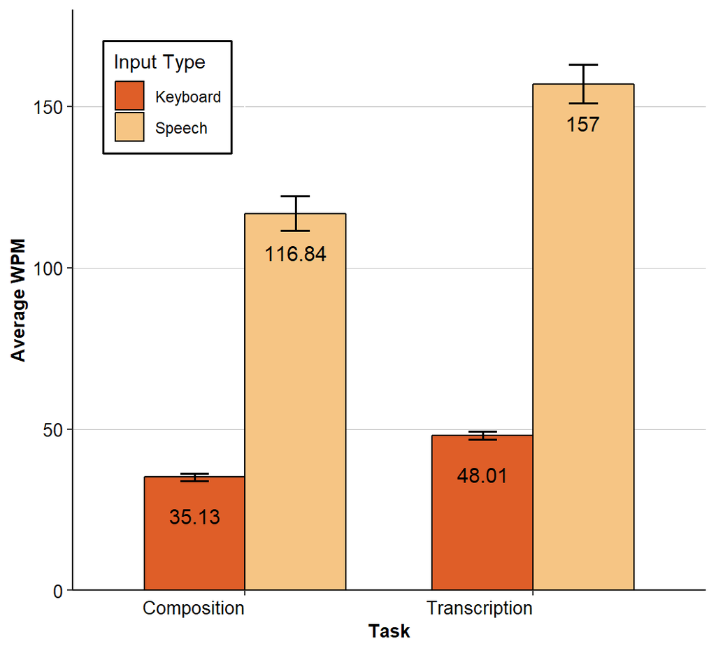

```r
createPlot(data.stats, "mWpm", "clWpm", "cuWpm", 3, .15, .85, "Average WPM", 0, 180, 50)
```

## 6.3 Effects of SetNum

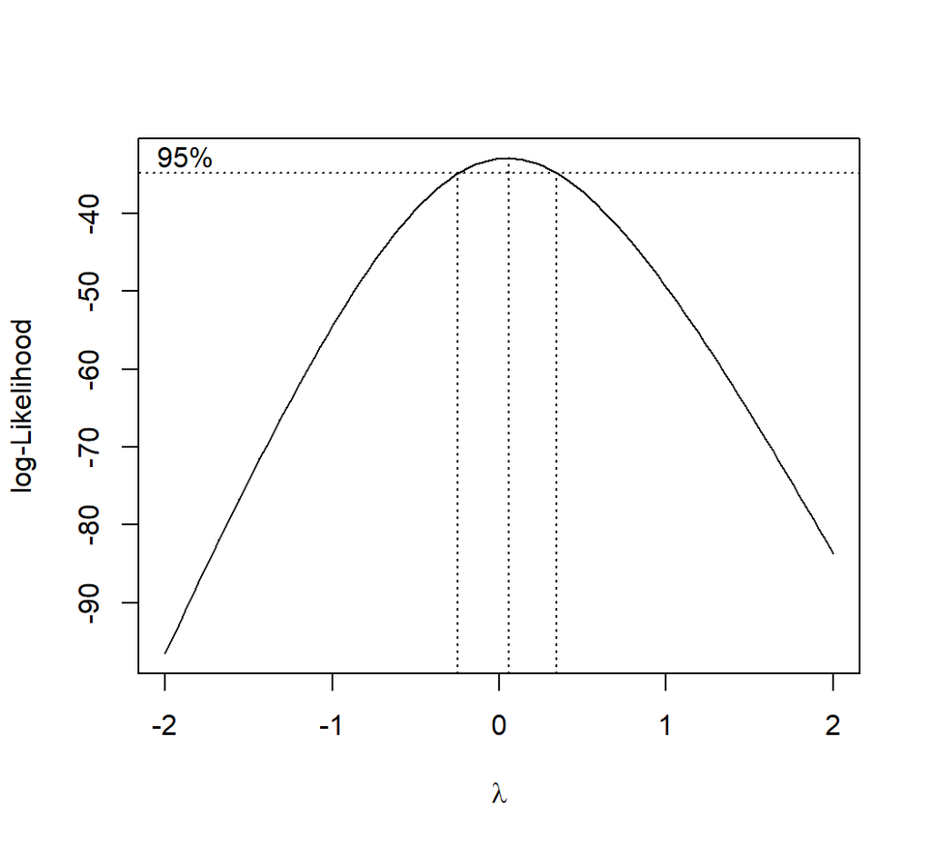

```r
boxcox(meanWpm ~ inputType*setNum, data=data.long.c, plotit=T)
```

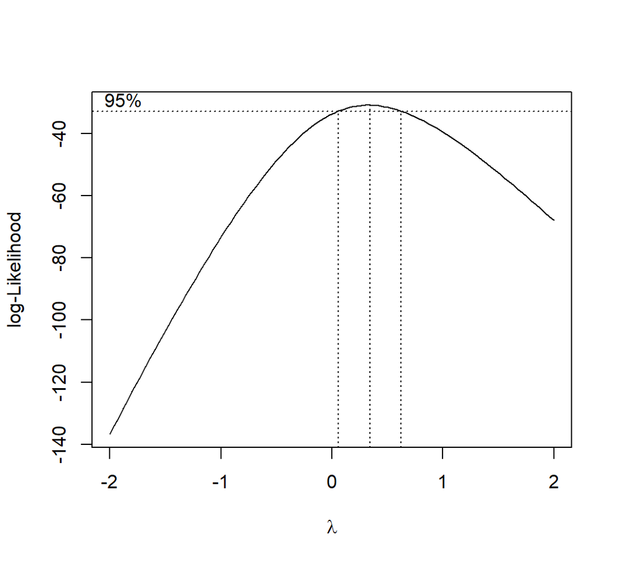

```r
boxcox(meanWpm ~ inputType*setNum, data=data.long.t, plotit=T)
```

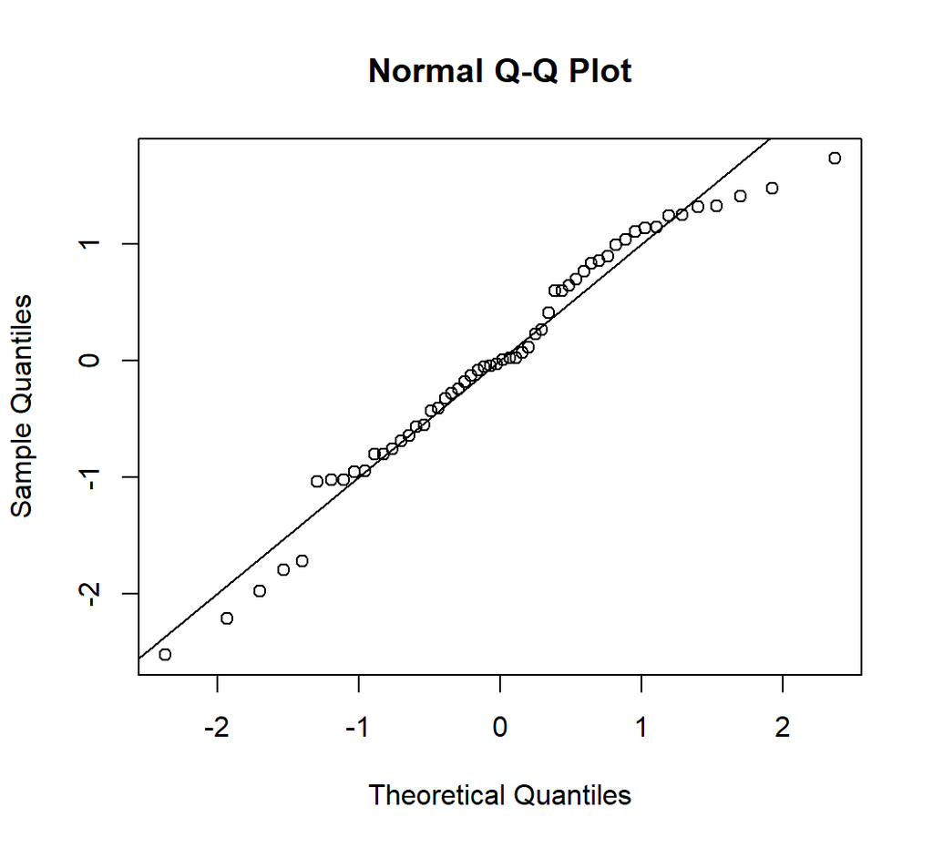

```r
datatr.c = data.long.c %>% mutate(meanWpm = log(meanWpm))
datatr.t = data.long.t %>% mutate(meanWpm = meanWpm^(0.28))

m <- aov(meanWpm ~ inputType*setNum, data=datatr.c)
pander(normalCheck(m))
```

Shapiro-Wilk normality test

data: res W = 0.96805, p-value = 0.143

Shapiro-Wilk normality test: `res`

| Test statistic | P value |
| --- | --- |
| 0.968 | 0.143 |

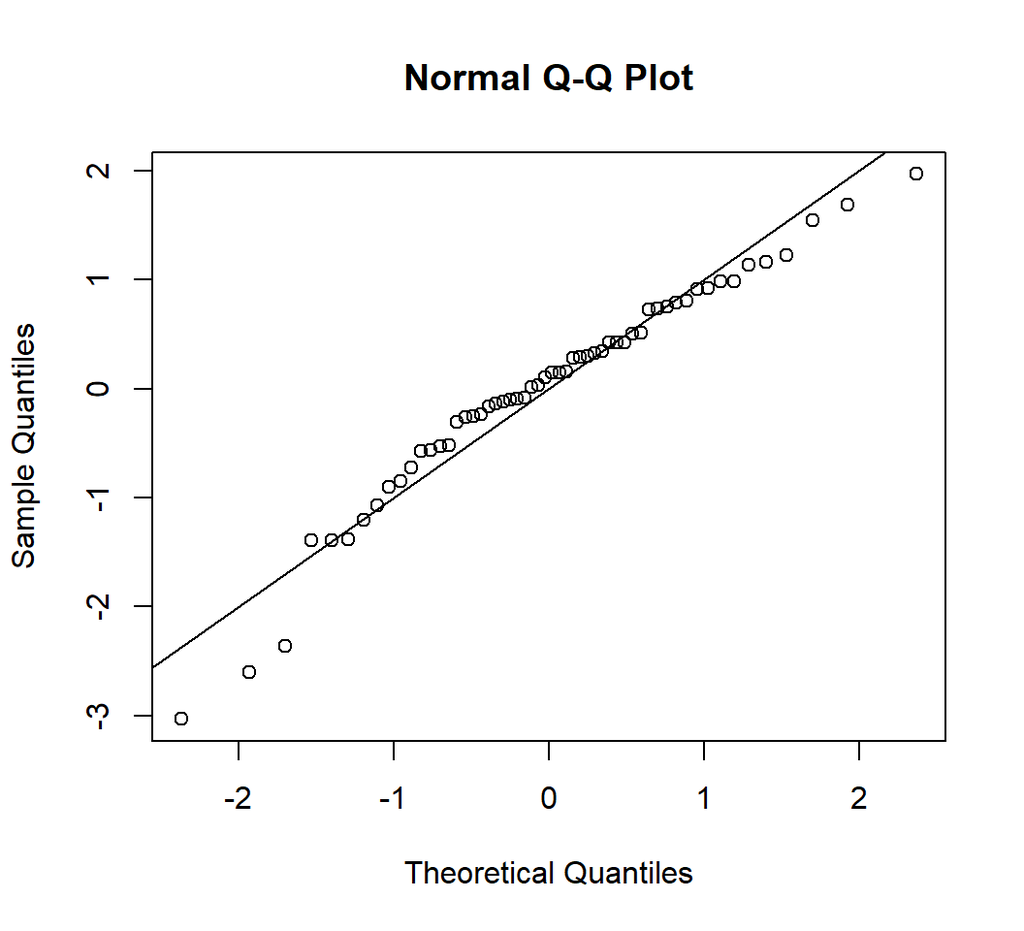

```r
m <- aov(meanWpm ~ setNum*inputType, data=datatr.t)
pander(normalCheck(m))
```

Shapiro-Wilk normality test

data: res W = 0.95452, p-value = 0.03401

Shapiro-Wilk normality test: `res`

| Test statistic | P value |
| --- | --- |
| 0.9545 | 0.03401 * |

```r
anova = ezANOVA(datatr.c, dv=.(meanWpm), wid=.(participantNo), within=.(setNum), detailed=TRUE)
kable(anova_apa(anova, sph_corr ="gg", es = "ges", print=FALSE))
```

| effect | text |
| --- | --- |
| (Intercept) | F(1, 27) = 14785.20, p < .001, getasq = .98 |
| setNum | F(1, 27) = 0.04, p = .839, getasq < .01 |

```r
anova = ezANOVA(datatr.t, dv=.(meanWpm), wid=.(participantNo), within=.(setNum), detailed=TRUE)
kable(anova_apa(anova, sph_corr ="gg", es = "ges", print=FALSE))
```

| effect | text |
| --- | --- |
| (Intercept) | F(1, 27) = 13654.89, p < .001, getasq = .97 |
| setNum | F(1, 27) = 0.15, p = .699, getasq < .01 |

No significant effect of setNum on WPM.

## 6.4 Effects of Input Type and Task Type

### 6.4.1 Normality Check

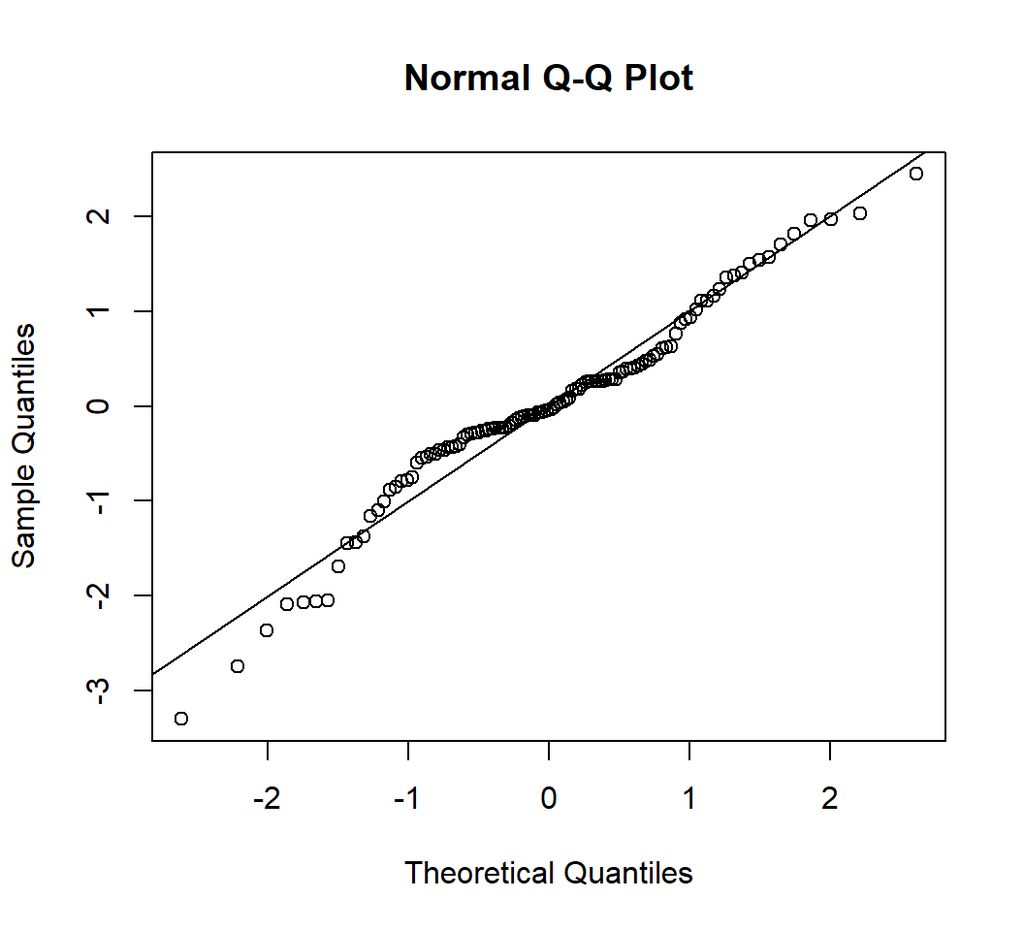

```r
m <- aov(meanWpm ~ taskType*inputType, data=data.long)
pander(normalCheck(m))
```

Shapiro-Wilk normality test

data: res W = 0.96315, p-value = 0.003515

Shapiro-Wilk normality test: `res`

| Test statistic | P value |
| --- | --- |
| 0.9632 | 0.003515 * * |

The data is not normally distributed.

### 6.4.2 Box-Cox Transformation

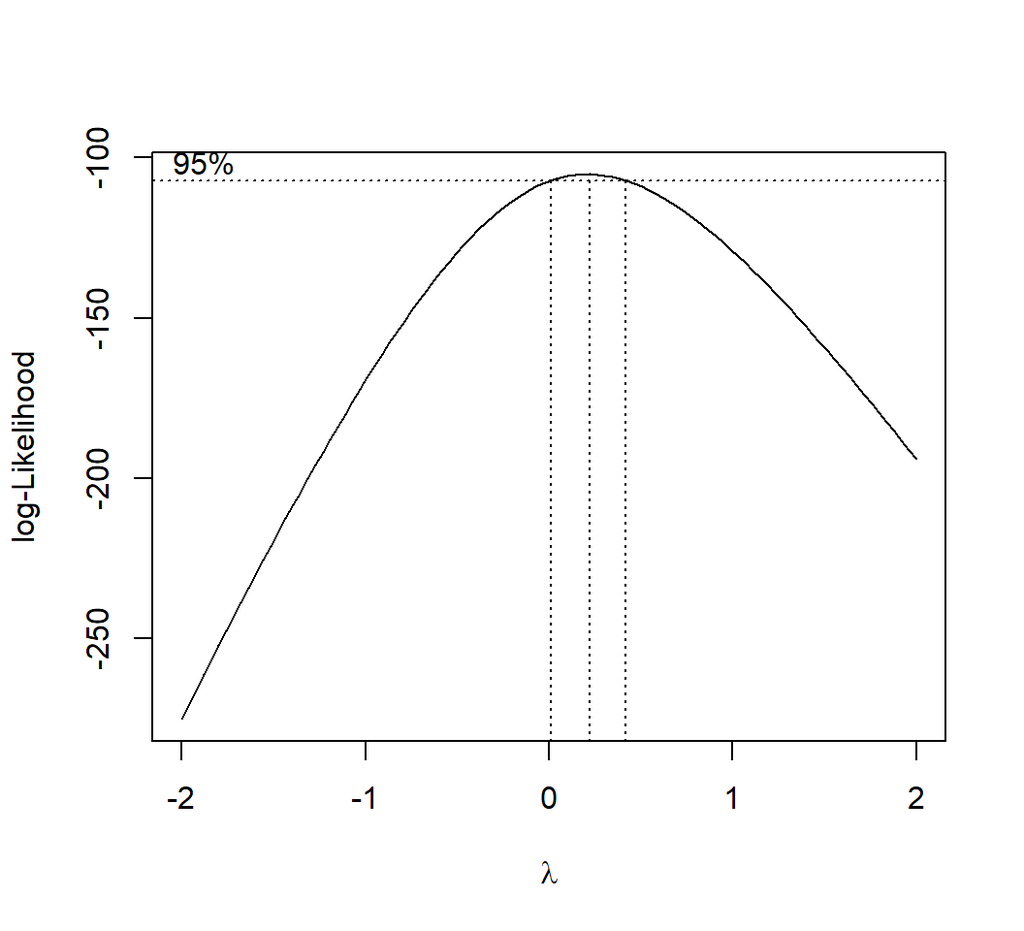

```r
boxcox(meanWpm ~ inputType*taskType, data=data.long, plotit=T)
```

An effective lambda value is 0.2

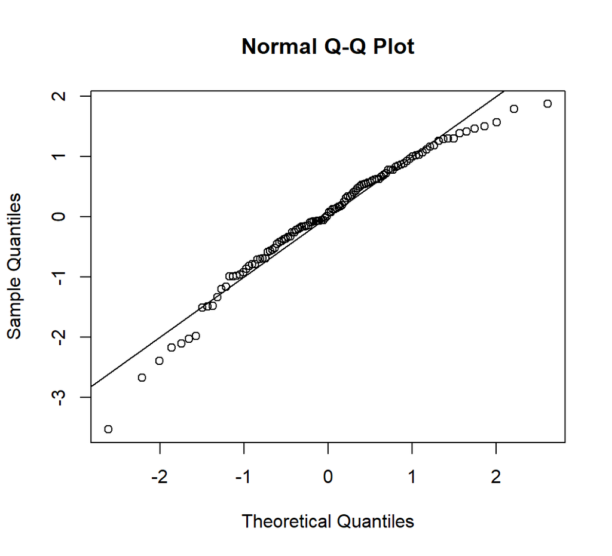

```r
datatr = data.long %>%
    mutate(meanWpm = meanWpm^(0.2))

m <- aov(meanWpm ~ taskType*inputType, data=datatr)
pander(normalCheck(m))
```

Shapiro-Wilk normality test

data: res W = 0.96605, p-value = 0.005995

Shapiro-Wilk normality test: `res`

| Test statistic | P value |
| --- | --- |
| 0.9661 | 0.005995 * * |

### 6.4.3 Repeated measures ANOVA on transformed data

```r
anova = ezANOVA(datatr, dv=.(meanWpm), wid=.(participantNo), within=.(inputType,taskType), detailed=TRUE)

anova_apa = anova_apa(anova, sph_corr ="gg", es = "ges", print=FALSE)
input = anova_apa$text[2]
task = anova_apa$text[3]
inter = anova_apa$text[4]
kable(anova_apa)
```

| effect | text |
| --- | --- |
| (Intercept) | F(1, 27) = 32787.26, p < .001, getasq > .99 |
| inputType | F(1, 27) = 500.80, p < .001, getasq = .86 |
| taskType | F(1, 27) = 77.02, p < .001, getasq = .28 |
| inputType:taskType | F(1, 27) = 1.22, p = .280, getasq < .01 |

There are significant differences between Keyboard and Speech, and Composition and Transcription, but not the interaction between the two.

```python
s = "There were significant differences between \\f{speech} and \\f{keyboard} (%s), and between \\f{composition} and \\f{transcription} on Box-Cox transformed \\m{WPM} (%s)." % (parseAnova(r.input), parseAnova(r.task))
writeToFile(s, "wpm.tex")
```

# 7 Corrected Error Rate

## 7.1 Chart

```r
kable(dplyr::select(data.stats, inputType, taskType, m_cer, sd_cer))
```

| inputType | taskType | m_cer | sd_cer |
| --- | --- | --- | --- |
| Keyboard | Composition | 0.1700720 | 0.1780495 |
| Keyboard | Transcription | 0.1128971 | 0.1255004 |
| Speech | Composition | 0.1752152 | 0.3535872 |
| Speech | Transcription | 0.1417668 | 0.2990412 |

## 7.2 Bar Graph

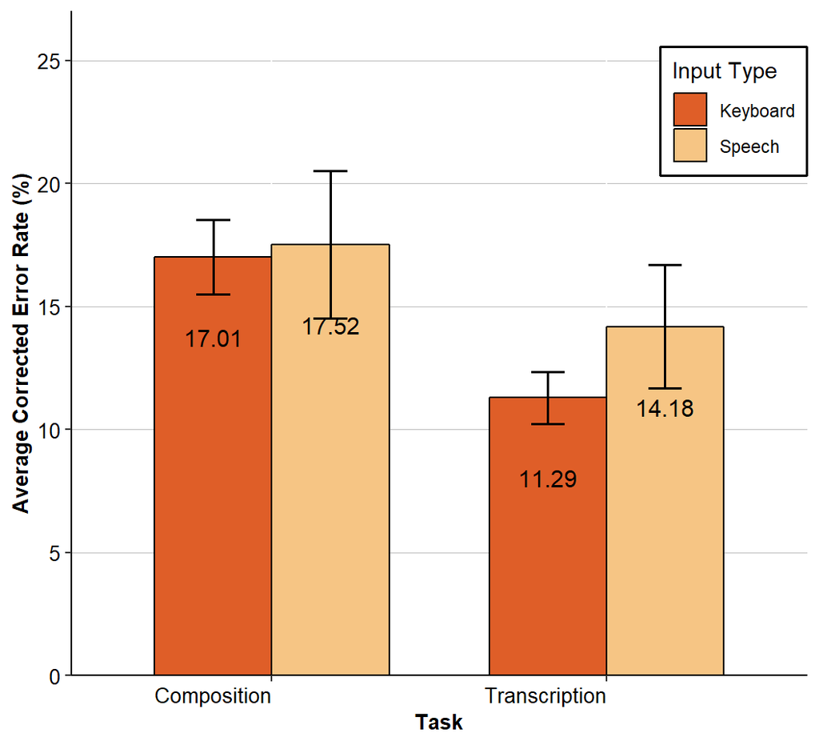

```r
createPlot(data.stats, "m_cer", "cl_cer", "cu_cer", 5, 0.9, 0.85, "Average Corrected Error Rate (%)", 0, 27, 5)
```

## 7.3 Effects of SetNum

```r
a = art(mean_cer ~ setNum + (1|participantNo), data=data.long.c)
anova(a)
```

```
## Analysis of Variance of Aligned Rank Transformed Data
##
## Table Type: Analysis of Deviance Table (Type III Wald F tests with Kenward-Roger df)
## Model: Mixed Effects (lmer)
## Response: art(mean_cer)
##
##                 F Df Df.res  Pr(>F)
## 1 setNum 0.069434  1     27 0.79416
## ---
## Signif. codes:   0 '***' 0.001 '**' 0.01 '*' 0.05 '.' 0.1 ' ' 1
```

```r
a = art(mean_cer ~ setNum + (1|participantNo), data=data.long.t)
anova(a)
```

```
## Analysis of Variance of Aligned Rank Transformed Data
##
## Table Type: Analysis of Deviance Table (Type III Wald F tests with Kenward-Roger df)
## Model: Mixed Effects (lmer)
## Response: art(mean_cer)
##
##                F Df Df.res  Pr(>F)
## 1 setNum 0.72244  1     27 0.40282
## ---
## Signif. codes:   0 '***' 0.001 '**' 0.01 '*' 0.05 '.' 0.1 ' ' 1
```

No significant effect of setNum on CER

## 7.4 Effects of Input Type and Task Type

### 7.4.1 Normality Check

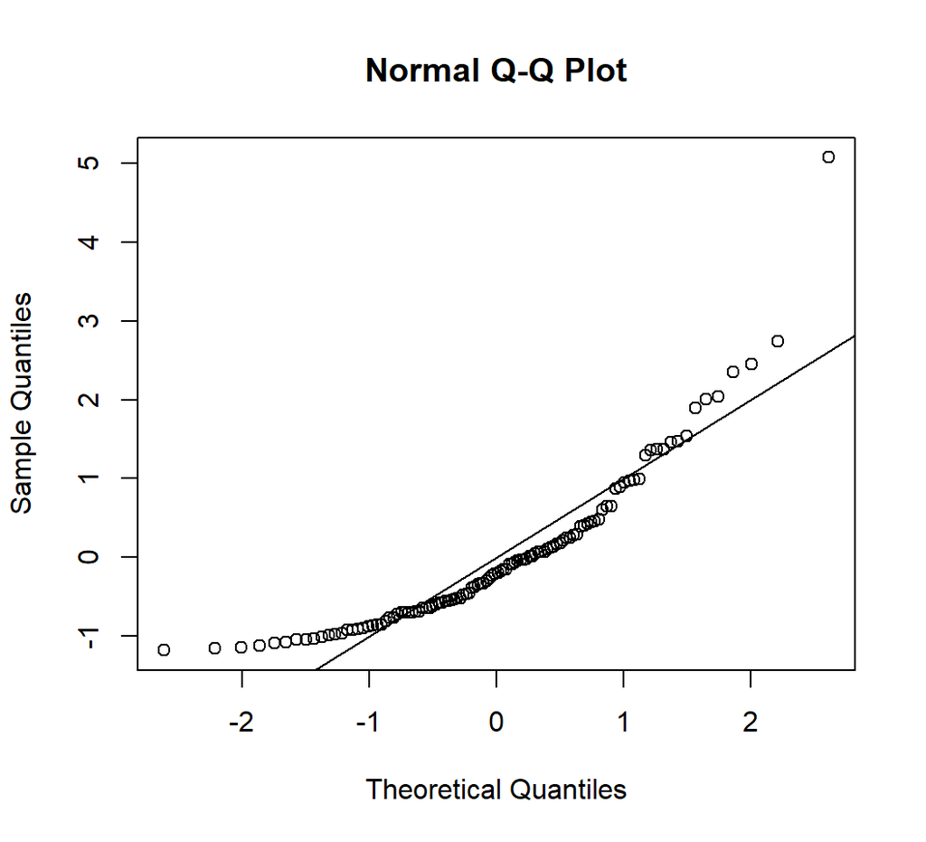

```r
m <- aov(mean_cer ~ taskType*inputType, data=data.long)
pander(normalCheck(m))
```

Shapiro-Wilk normality test

data: res W = 0.8538, p-value = 3.924e-09

Shapiro-Wilk normality test: `res`

| Test statistic | P value |
| --- | --- |
| 0.8538 | 3.924e-09 * * * |

The data is not normally distributed.

### 7.4.2 ANOVAs in ART Data

```r
a = art(mean_cer ~ taskType*inputType + (1|participantNo), data=data.long)
anova(a)
```

```
## Analysis of Variance of Aligned Rank Transformed Data
##
## Table Type: Analysis of Deviance Table (Type III Wald F tests with Kenward-Roger df)
## Model: Mixed Effects (lmer)
## Response: art(mean_cer)
##
##                            F Df Df.res   Pr(>F)
## 1 taskType           5.75341  1     81 0.018755 *
## 2 inputType          0.43186  1     81 0.512940
## 3 taskType:inputType 1.08241  1     81 0.301255
## ---
## Signif. codes:   0 '***' 0.001 '**' 0.01 '*' 0.05 '.' 0.1 ' ' 1
```

# 8 Uncorrected Error Rate

## 8.1 Chart

```r
kable(dplyr::select(data.stats, inputType, taskType, m_uer, sd_cer))
```

| inputType | taskType | m_uer | sd_cer |
| --- | --- | --- | --- |
| Keyboard | Composition | 0.0047877 | 0.1780495 |
| Keyboard | Transcription | 0.0034189 | 0.1255004 |
| Speech | Composition | 0.0068828 | 0.3535872 |
| Speech | Transcription | 0.0089248 | 0.2990412 |

## 8.2 Bar Graph

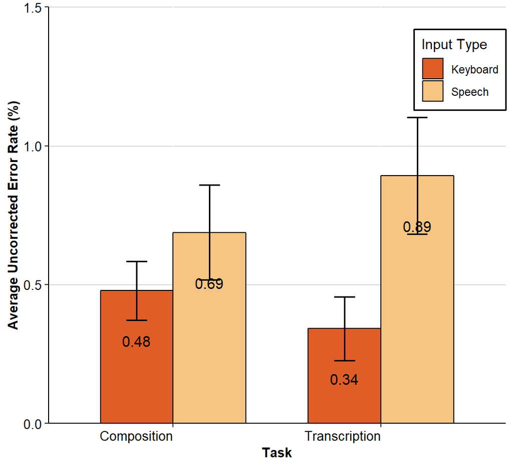

```r
createPlot(data.stats, "m_uer", "cl_uer", "cu_uer", 5, 0.9, 0.85, "Average Uncorrected Error Rate (%)", 0, 1.5, 0.3)
```

## 8.3 Effects of SetNum

```r
a = art(mean_uer ~ setNum + (1|participantNo), data=data.long.c)
anova(a)
```

```
## Analysis of Variance of Aligned Rank Transformed Data
##
## Table Type: Analysis of Deviance Table (Type III Wald F tests with Kenward-Roger df)
## Model: Mixed Effects (lmer)
## Response: art(mean_uer)
##
##                  F Df Df.res  Pr(>F)
## 1 setNum 0.0071299  1     27 0.93333
## ---
## Signif. codes:   0 '***' 0.001 '**' 0.01 '*' 0.05 '.' 0.1 ' ' 1
```

```r
a = art(mean_uer ~ setNum + (1|participantNo), data=data.long.t)
anova(a)
```

```
## Analysis of Variance of Aligned Rank Transformed Data
##
## Table Type: Analysis of Deviance Table (Type III Wald F tests with Kenward-Roger df)
## Model: Mixed Effects (lmer)
## Response: art(mean_uer)
##
##                F Df Df.res  Pr(>F)
## 1 setNum 0.55952  1     27 0.46092
## ---
## Signif. codes:   0 '***' 0.001 '**' 0.01 '*' 0.05 '.' 0.1 ' ' 1
```

No significant effect of setNum on UER

## 8.4 Effects of Input Type and Task Type

### 8.4.1 Normality Check

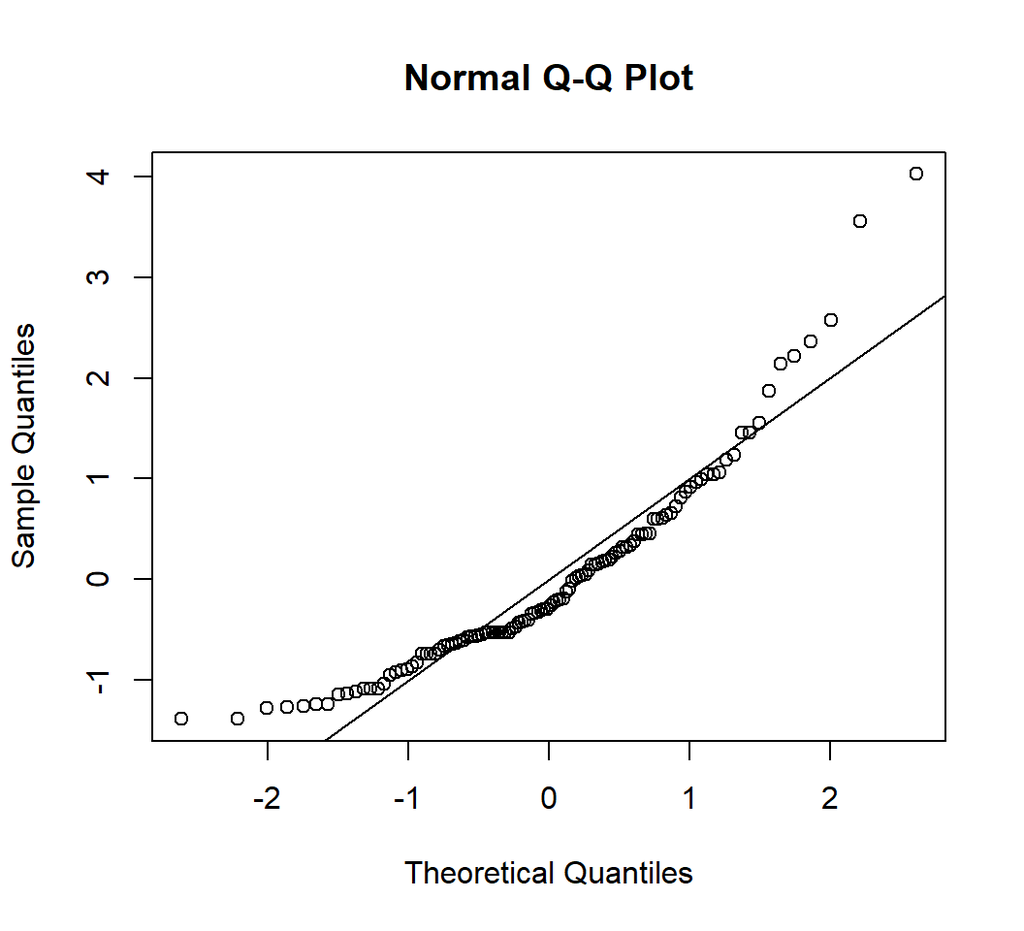

```r
m <- aov(mean_uer ~ taskType*inputType, data=data.long)
pander(normalCheck(m))
```

Shapiro-Wilk normality test

data: res W = 0.8964, p-value = 2.823e-07

Shapiro-Wilk normality test: `res`

| Test statistic | P value |
| --- | --- |
| 0.8964 | 2.823e-07 * * * |

The data is not normally distributed.

### 8.4.2 ANOVAs on ART Data

```r
a = art(mean_uer ~ taskType*inputType + (1|participantNo), data=data.long)
anova(a)
```

```
## Analysis of Variance of Aligned Rank Transformed Data
##
## Table Type: Analysis of Deviance Table (Type III Wald F tests with Kenward-Roger df)
## Model: Mixed Effects (lmer)
## Response: art(mean_uer)
##
##                            F Df Df.res     Pr(>F)
## 1 taskType            1.0960  1     81 0.29825861
## 2 inputType          12.6895  1     81 0.00061936 ***
## 3 taskType:inputType  2.2439  1     81 0.13803174
## ---
## Signif. codes:   0 '***' 0.001 '**' 0.01 '*' 0.05 '.' 0.1 ' ' 1
```

Significant effect of inputType.

# 9 Bandwidth

## 9.1 Chart

```r
kable(dplyr::select(data.stats, inputType, taskType, m_bd, sdBD))
```

| inputType | taskType | m_bd | sdBD |
| --- | --- | --- | --- |
| Keyboard | Composition | 0.7772612 | 0.1790421 |
| Keyboard | Transcription | 0.8548765 | 0.1357257 |
| Speech | Composition | 0.8630774 | 0.2014877 |
| Speech | Transcription | 0.8881524 | 0.1789904 |

## 9.2 Bar Graph

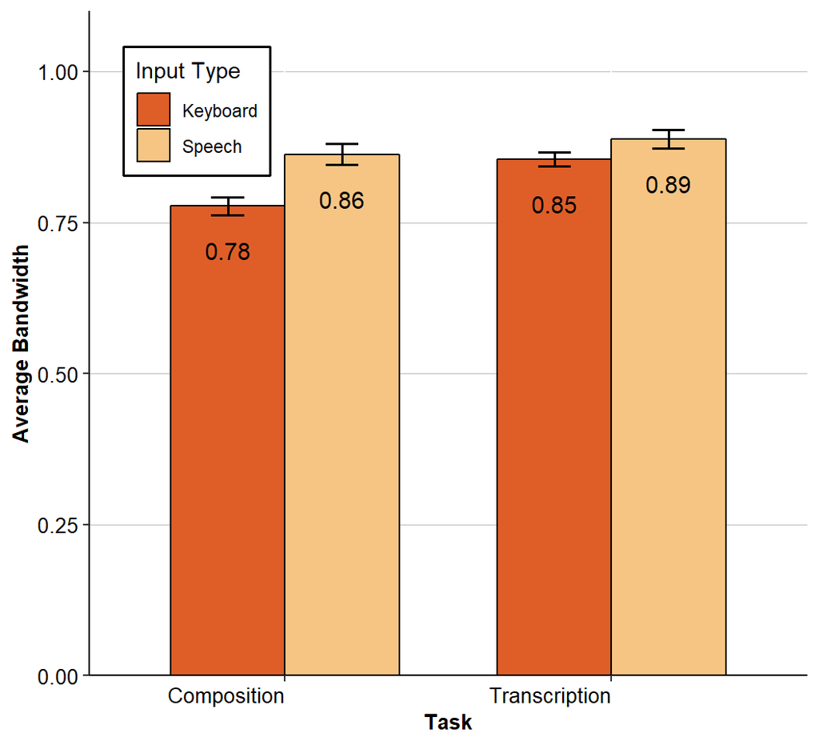

```r
createPlot(data.stats, "m_bd", "clBD", "cuBD", 3, .15, .85, "Average Bandwidth", 0, 1.1, .3)
```

## 9.3 Effects of SetNum

```r
a = art(mean_bd ~ setNum + (1|participantNo), data=data.long.c)
anova(a)
```

```
## Analysis of Variance of Aligned Rank Transformed Data
##
## Table Type: Analysis of Deviance Table (Type III Wald F tests with Kenward-Roger df)
## Model: Mixed Effects (lmer)
## Response: art(mean_bd)
##
##                F Df Df.res  Pr(>F)
## 1 setNum 0.13243  1     27 0.71876
## ---
## Signif. codes:   0 '***' 0.001 '**' 0.01 '*' 0.05 '.' 0.1 ' ' 1
```

```r
a = art(mean_bd ~ setNum + (1|participantNo), data=data.long.t)
anova(a)
```

```
## Analysis of Variance of Aligned Rank Transformed Data
##
## Table Type: Analysis of Deviance Table (Type III Wald F tests with Kenward-Roger df)
## Model: Mixed Effects (lmer)
## Response: art(mean_bd)
##
##                F Df Df.res  Pr(>F)
## 1 setNum 0.64052  1     27 0.43051
## ---
## Signif. codes:   0 '***' 0.001 '**' 0.01 '*' 0.05 '.' 0.1 ' ' 1
```

No effect of setNum

## 9.4 Effects of Input Type and Task Type

### 9.4.1 Normality Check

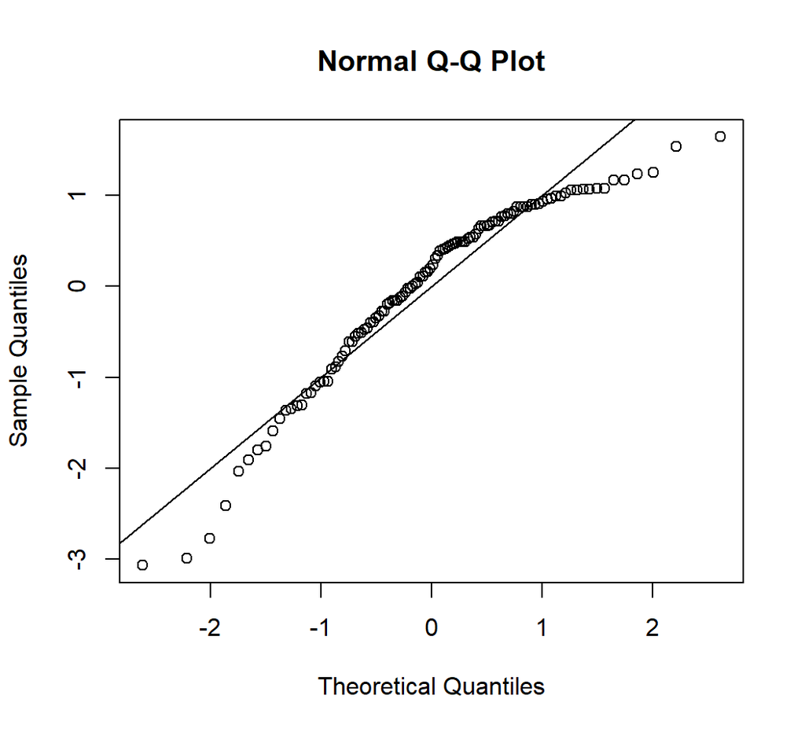

```r
m <- aov(mean_bd ~ taskType*inputType, data=data.long)
pander(normalCheck(m))
```

Shapiro-Wilk normality test

data: res W = 0.92672, p-value = 1.168e-05

Shapiro-Wilk normality test: `res`

| Test statistic | P value |
| --- | --- |
| 0.9267 | 1.168e-05 * * * |

The data is not normally distributed.

### 9.4.2 ANOVAs on ART Data

```r
a = art(mean_bd ~ taskType*inputType + (1|participantNo), data=data.long)
anova(a)
```

```
## Analysis of Variance of Aligned Rank Transformed Data
##
## Table Type: Analysis of Deviance Table (Type III Wald F tests with Kenward-Roger df)
## Model: Mixed Effects (lmer)
## Response: art(mean_bd)
##
##                            F Df Df.res     Pr(>F)
## 1 taskType           16.1307  1     81 0.00013144 ***
## 2 inputType          24.8116  1     81 3.5127e-06 ***
## 3 taskType:inputType  5.1443  1     81 0.02598458   *
## ---
## Signif. codes:   0 '***' 0.001 '**' 0.01 '*' 0.05 '.' 0.1 ' ' 1
```

Significant effect of taskType, inputType, and their interaction.

### 9.4.3 Post-hoc comparisons

Used Mann-Whitney U tests because nothing else worked :/

```r
kt_vs_st = wilcox.test(data.long[data.long$taskType == "Transcription" & data.long$inputType == "Keyboard",]$mean_bd,
                       data.long[data.long$taskType == "Transcription" & data.long$inputType == "Speech",]$mean_bd)$p.value
kc_vs_sc = wilcox.test(data.long[data.long$taskType == "Composition" & data.long$inputType == "Keyboard",]$mean_bd,
                       data.long[data.long$taskType == "Composition" & data.long$inputType == "Speech",]$mean_bd)$p.value
kc_vs_kt = wilcox.test(data.long[data.long$taskType == "Composition" & data.long$inputType == "Keyboard",]$mean_bd,
                       data.long[data.long$taskType == "Transcription" & data.long$inputType == "Keyboard",]$mean_bd)$p.value
sc_vs_st = wilcox.test(data.long[data.long$taskType == "Composition" & data.long$inputType == "Speech",]$mean_bd,
                       data.long[data.long$taskType == "Transcription" & data.long$inputType == "Speech",]$mean_bd)$p.value
kt_vs_st
```

```
## [1] 0.1143034
```

```r
kc_vs_sc
```

```
## [1] 0.0004219234
```

```r
kc_vs_kt
```

```
## [1] 0.001202385
```

```r
sc_vs_st
```

```
## [1] 0.2782206
```

Keyboard:Composition vs Speech:Compostion and Keyboard:Composition vs Keyboard:Transcription are significant.

# 10 Composition Data

14 participants preferred the keyboard, 12 preferred speech, and 1 participant had no strong preference (they gave reasons for liking/not liking either input method). A slight majority, but not as big as I was hoping for….

# 11 Transcription Data

Subjectively, 26 participants preferred Speech to typing - a massive majority.

# 12 Figures